# Loading..

### **Encoding Target Variable using LabelBinaizer**

```python
from sklearn.preprocessing import LabelBinarizer
  # Storing the LabelBinarizer function in lb variable
  lb = LabelBinarizer()
  # Applying fit_transform on train target variable
  y_train_e = lb.fit_transform(y_train)
  # Applying only transform on test target variable
  y_test_e = lb.transform(y_test)
```

### **Convolutional Neural Network - Model 1**

```python
from tensorflow.keras import backend
  backend.clear_session()
  #Fixing the seed for random number generators so that we can ensure we receive the same output everytime
  np.random.seed(42)
  import random
  random.seed(42)
  tf.random.set_seed(42)
```

```python
# Intializing a sequential model
  model1 = Sequential()

  # Adding first conv layer with 64 filters and kernel size 3x3 , padding 'same' provides the output size same as the input size
  # Input_shape denotes input image dimension of MNIST images
  model1.add(Conv2D(64, (3, 3), activation='relu', padding="same", input_shape=(150,150,3)))

  # Adding max pooling to reduce the size of output of first conv layer
  model1.add(MaxPooling2D((2, 2), padding = 'same'))

  model1.add(Conv2D(32, (3, 3), activation='relu', padding="same"))
  model1.add(MaxPooling2D((2, 2), padding = 'same'))
  model1.add(Conv2D(32, (3, 3), activation='relu', padding="same"))
  model1.add(MaxPooling2D((2, 2), padding = 'same'))

  # flattening the output of the conv layer after max pooling to make it ready for creating dense connections
  model1.add(Flatten())

  # Adding a fully connected dense layer with 100 neurons
  model1.add(Dense(100, activation='relu'))

  # Adding the output layer with 10 neurons and activation functions as softmax since this is a multi-class classification problem
  model1.add(Dense(3, activation='softmax'))

  # Using SGD Optimizer
  opt = SGD(learning_rate=0.01, momentum=0.9)

  # Compile model
  model1.compile(optimizer=opt, loss='categorical_crossentropy', metrics=['accuracy'])

  # Generating the summary of the model
  model1.summary()
```

```
Model: "sequential"
  _________________________________________________________________
   Layer (type)                Output Shape              Param #
  =================================================================
   conv2d (Conv2D)             (None, 150, 150, 64)      1792

   max_pooling2d (MaxPooling2  (None, 75, 75, 64)        0
   D)

   conv2d_1 (Conv2D)           (None, 75, 75, 32)        18464

   max_pooling2d_1 (MaxPoolin  (None, 38, 38, 32)        0
   g2D)

   conv2d_2 (Conv2D)           (None, 38, 38, 32)        9248

   max_pooling2d_2 (MaxPoolin  (None, 19, 19, 32)        0
   g2D)

   flatten (Flatten)           (None, 11552)             0

   dense (Dense)               (None, 100)               1155300

   dense_1 (Dense)             (None, 3)                 303

  =================================================================
  Total params: 1185107 (4.52 MB)
  Trainable params: 1185107 (4.52 MB)
  Non-trainable params: 0 (0.00 Byte)
  _________________________________________________________________
```

```python
es1 = EarlyStopping(monitor='val_loss', mode='min', verbose=1, patience=5)
  mc1 = ModelCheckpoint('best_model.h5', monitor='val_accuracy', mode='max', verbose=1, save_best_only=True)
  # Fitting the model with 30 epochs and validation_split as 10%
  history1=model1.fit(X_train,
            y_train_e,
            epochs=30,
            batch_size=32,validation_split=0.10,callbacks=[es1, mc1])
```

```
  Epoch 1: val_accuracy improved from -inf to 0.44860, saving model to best_model.h5
```

```
  Epoch 2: val_accuracy improved from 0.44860 to 0.47664, saving model to best_model.h5
  Epoch 3: val_accuracy did not improve from 0.47664
  Epoch 4: val_accuracy did not improve from 0.47664
  Epoch 5: val_accuracy did not improve from 0.47664
  Epoch 6: val_accuracy did not improve from 0.47664
  Epoch 7: val_accuracy improved from 0.47664 to 0.58255, saving model to best_model.h5
  Epoch 8: val_accuracy did not improve from 0.58255
  Epoch 9: val_accuracy improved from 0.58255 to 0.61994, saving model to best_model.h5
  Epoch 10: val_accuracy did not improve from 0.61994
  Epoch 11: val_accuracy improved from 0.61994 to 0.64486, saving model to best_model.h5
  Epoch 12: val_accuracy did not improve from 0.64486
  Epoch 13: val_accuracy did not improve from 0.64486
  Epoch 14: val_accuracy improved from 0.64486 to 0.68536, saving model to best_model.h5
  Epoch 15: val_accuracy did not improve from 0.68536
  Epoch 16: val_accuracy improved from 0.68536 to 0.68847, saving model to best_model.h5
  Epoch 17: val_accuracy improved from 0.68847 to 0.70093, saving model to best_model.h5
  Epoch 18: val_accuracy did not improve from 0.70093
  Epoch 19: val_accuracy did not improve from 0.70093
  Epoch 19: early stopping
```

**Plotting Accuracy vs Epoch Curve**

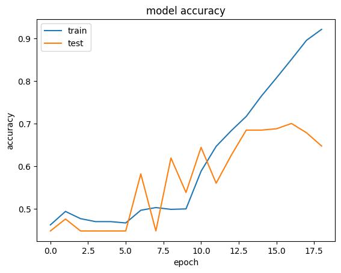

```python
plt.plot(history1.history['accuracy'])
  plt.plot(history1.history['val_accuracy'])
  plt.title('model accuracy')
  plt.ylabel('accuracy')
  plt.xlabel('epoch')
  plt.legend(['train', 'test'], loc='upper left')
  plt.show()
```

From the above plot, it seems that the model is overfitting, lets try to use Dropout in the next model.

```python
model1.evaluate(X_test,(y_test_e))
```

```
[463.7076721191406, 0.5438756942749023]
```

```python
# Test Prediction
  y_test_pred_ln1 = model1.predict(X_test)
  y_test_pred_classes_ln1 = np.argmax(y_test_pred_ln1, axis=1)
  normal_y_test = np.argmax(y_test_e, axis=1)
```

```python
# Test Accuracy
  import seaborn as sns
  from sklearn.metrics import accuracy_score, confusion_matrix
  accuracy_score((normal_y_test), y_test_pred_classes_ln1)
```

```
0.5438756855575868
```

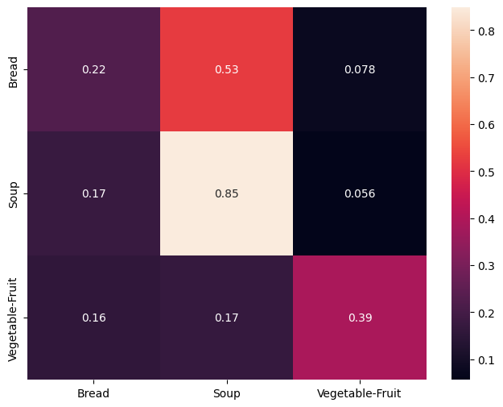

```python
cf_matrix = confusion_matrix(normal_y_test, y_test_pred_classes_ln1)

  # Confusion matrix normalized per category true value
  cf_matrix_n1 = cf_matrix/np.sum(cf_matrix, axis=1)
  plt.figure(figsize=(8,6))
  sns.heatmap(cf_matrix_n1, xticklabels=CATEGORIES, yticklabels=CATEGORIES, annot=True)
```

### **Convolutional Neural Network Model 2**

```python
from tensorflow.keras import backend
  backend.clear_session()
  #Fixing the seed for random number generators so that we can ensure we receive the same output everytime
  np.random.seed(42)
  import random
  random.seed(42)
  tf.random.set_seed(42)
```

```python
# initialized a sequential model
  model_2 = Sequential()
  # adding first conv layer with 256 filters and kernel size 5x5 , with ReLU activation and padding 'same' provides the output size same as the input size
  #input_shape denotes input image dimension of images
  model_2.add(Conv2D(filters = 256, kernel_size = (5,5),padding = 'Same',
                   activation ='relu', input_shape = (150,150,3)))
  # adding max pooling to reduce the size of output of first conv layer
  model_2.add(MaxPool2D(pool_size=(2,2)))
  #  adding dropout to randomly switch off 25% neurons to reduce overfitting

  # adding second conv layer with 256 filters and with kernel size 3x3 and ReLu activation function
  model_2.add(Conv2D(filters = 128, kernel_size = (5,5),padding = 'Same',
                   activation ='relu'))
  # adding max pooling to reduce the size of output of first conv layer
  model_2.add(MaxPool2D(pool_size=(2,2), strides=(2,2)))
  #  adding dropout to randomly switch off 25% neurons to reduce overfitting

  # adding third conv layer with 256 filters and with kernel size 3x3 and ReLu activation function
  model_2.add(Conv2D(filters = 64, kernel_size = (3,3),padding = 'Same',
                   activation ='relu'))
  # adding max pooling to reduce the size of output of first conv layer
  model_2.add(MaxPool2D(pool_size=(2,2), strides=(2,2)))
  #  adding dropout to randomly switch off 30% neurons to reduce overfitting
  model_2.add(Dropout(0.3))

  # adding forth conv layer with 256 filters and with kernel size 3x3 and ReLu activation function
  model_2.add(Conv2D(filters = 32, kernel_size = (3,3),padding = 'Same',
                   activation ='relu'))
  # adding max pooling to reduce the size of output of first conv layer
  model_2.add(MaxPool2D(pool_size=(2,2), strides=(2,2)))
  #  adding dropout to randomly switch off 30% neurons to reduce overfitting
  model_2.add(Dropout(0.3))

  # flattening the 3-d output of the conv layer after max pooling to make it ready for creating dense connections
  model_2.add(Flatten())
  # adding first fully connected dense layer with 1024 neurons
  model_2.add(Dense(64, activation = "relu"))
  #  adding dropout to randomly switch off 50% neurons to reduce overfitting
  model_2.add(Dropout(0.5))
  # adding second fully connected dense layer with 512 neurons
  model_2.add(Dense(32, activation = "relu"))
  #  adding dropout to randomly switch off 50% neurons to reduce overfitting
  model_2.add(Dropout(0.5))

  # adding the output layer with 4 neurons and activation functions as softmax since this is a multi-class classification problem with 4 classes.
  model_2.add(Dense(3, activation = "softmax"))
```

```python
model_2.summary()
```

```
Model: "sequential"
  _________________________________________________________________
   Layer (type)                Output Shape              Param #
  =================================================================
   conv2d (Conv2D)             (None, 150, 150, 256)     19456

   max_pooling2d (MaxPooling2  (None, 75, 75, 256)       0
   D)

   conv2d_1 (Conv2D)           (None, 75, 75, 128)       819328

   max_pooling2d_1 (MaxPoolin  (None, 37, 37, 128)       0
   g2D)

   conv2d_2 (Conv2D)           (None, 37, 37, 64)        73792

   max_pooling2d_2 (MaxPoolin  (None, 18, 18, 64)        0
   g2D)

   dropout (Dropout)           (None, 18, 18, 64)        0

   conv2d_3 (Conv2D)           (None, 18, 18, 32)        18464

   max_pooling2d_3 (MaxPoolin  (None, 9, 9, 32)          0
   g2D)

   dropout_1 (Dropout)         (None, 9, 9, 32)          0

   flatten (Flatten)           (None, 2592)              0

   dense (Dense)               (None, 64)                165952

   dropout_2 (Dropout)         (None, 64)                0

   dense_1 (Dense)             (None, 32)                2080

   dropout_3 (Dropout)         (None, 32)                0

   dense_2 (Dense)             (None, 3)                 99

  =================================================================
  Total params: 1099171 (4.19 MB)
  Trainable params: 1099171 (4.19 MB)
  Non-trainable params: 0 (0.00 Byte)
  _________________________________________________________________
```

As we can see from the above summary, this CNN model will train and learn **1,099,171 parameters (weights and biases).**

```python
optimizer = Adam(lr=0.001)
  model_2.compile(optimizer = optimizer , loss = "categorical_crossentropy", metrics=["accuracy"])
  es2 = EarlyStopping(monitor='val_loss', mode='min', verbose=1, patience=5)
  mc2 = ModelCheckpoint('best_model.h5', monitor='val_accuracy', mode='max', verbose=1, save_best_only=True)

  history2=model_2.fit(X_train,
            y_train_e,
            epochs=30,
            batch_size=32,validation_split=0.10,callbacks=[es2, mc2],use_multiprocessing=True)
```

```
WARNING:absl:`lr` is deprecated in Keras optimizer, please use `learning_rate` or use the legacy optimizer, e.g.,tf.keras.optimizers.legacy.Adam.
```

```
  Epoch 1: val_accuracy improved from -inf to 0.44860, saving model to best_model.h5
```

```
  Epoch 2: val_accuracy did not improve from 0.44860
  Epoch 3: val_accuracy did not improve from 0.44860
  Epoch 4: val_accuracy improved from 0.44860 to 0.55763, saving model to best_model.h5
  Epoch 5: val_accuracy improved from 0.55763 to 0.58255, saving model to best_model.h5
  Epoch 6: val_accuracy improved from 0.58255 to 0.63551, saving model to best_model.h5
  Epoch 7: val_accuracy did not improve from 0.63551
  Epoch 8: val_accuracy improved from 0.63551 to 0.69782, saving model to best_model.h5
  Epoch 9: val_accuracy did not improve from 0.69782
  Epoch 10: val_accuracy did not improve from 0.69782
  Epoch 11: val_accuracy improved from 0.69782 to 0.70717, saving model to best_model.h5
  Epoch 12: val_accuracy did not improve from 0.70717
  Epoch 13: val_accuracy did not improve from 0.70717
  Epoch 14: val_accuracy improved from 0.70717 to 0.76012, saving model to best_model.h5
  Epoch 15: val_accuracy did not improve from 0.76012
  Epoch 16: val_accuracy improved from 0.76012 to 0.77259, saving model to best_model.h5
  Epoch 17: val_accuracy did not improve from 0.77259
  Epoch 18: val_accuracy improved from 0.77259 to 0.79751, saving model to best_model.h5
  Epoch 19: val_accuracy did not improve from 0.79751
  Epoch 20: val_accuracy did not improve from 0.79751
  Epoch 21: val_accuracy improved from 0.79751 to 0.80374, saving model to best_model.h5
  Epoch 22: val_accuracy improved from 0.80374 to 0.82866, saving model to best_model.h5
  Epoch 23: val_accuracy did not improve from 0.82866
  Epoch 24: val_accuracy did not improve from 0.82866
  Epoch 25: val_accuracy did not improve from 0.82866
  Epoch 26: val_accuracy did not improve from 0.82866
  Epoch 27: val_accuracy did not improve from 0.82866
  Epoch 28: val_accuracy improved from 0.82866 to 0.85047, saving model to best_model.h5
  Epoch 29: val_accuracy did not improve from 0.85047
  Epoch 30: val_accuracy improved from 0.85047 to 0.85981, saving model to best_model.h5
```

**Plotting Accuracy vs Epoch Curve**

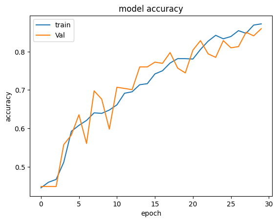

```python
plt.plot(history2.history['accuracy'])
  plt.plot(history2.history['val_accuracy'])
  plt.title('model accuracy')
  plt.ylabel('accuracy')
  plt.xlabel('epoch')
  plt.legend(['train', 'Val'], loc='upper left')
  plt.show()
```

Train and Validation accuracy seems fine and let's calculate the accuracy on the test data

```python
model_2.evaluate(X_test,y_test_e)
```

```
[86.3465576171875, 0.6755027174949646]
```

```python
y_test_pred_ln2 = model_2.predict(X_test)
  y_test_pred_classes_ln2 = np.argmax(y_test_pred_ln2, axis=1)
```

```python
import seaborn as sns
  from sklearn.metrics import accuracy_score, confusion_matrix
  accuracy_score(normal_y_test, y_test_pred_classes_ln2)
```

```
0.6755027422303473
```

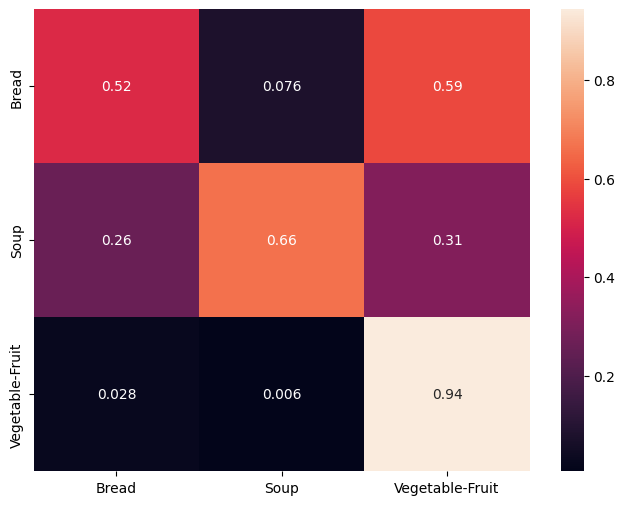

```python
cf_matrix = confusion_matrix(normal_y_test, y_test_pred_classes_ln2)

  # Confusion matrix normalized per category true value
  cf_matrix_n2 = cf_matrix/np.sum(cf_matrix, axis=1)
  plt.figure(figsize=(8,6))
  sns.heatmap(cf_matrix_n2, xticklabels=CATEGORIES, yticklabels=CATEGORIES, annot=True)
```

**Notes: Classification Report for each class**

- **Precision:** precision is the fraction of relevant instances among the retrieved instances.
- **Recall:** recall is the fraction of relevant instances that were retrieved.
- **F-beta score:** The F-beta score is the weighted harmonic mean of precision and recall, reaching its optimal value at 1 and its worst value at 0. The beta parameter determines the weight of recall in the combined score.

**CNN Model 1**

```python
from sklearn.metrics import classification_report
  print(classification_report((normal_y_test), y_test_pred_classes_ln1))
```

```
              precision    recall  f1-score   support

             0       0.40      0.22      0.29       362
             1       0.55      0.85      0.67       500
             2       0.74      0.39      0.51       232

      accuracy                           0.54      1094
     macro avg       0.57      0.49      0.49      1094
  weighted avg       0.54      0.54      0.51      1094
```

**CNN Model 2**

```python
from sklearn.metrics import classification_report
  print(classification_report(normal_y_test, y_test_pred_classes_ln2))
```

```
              precision    recall  f1-score   support

             0       0.64      0.52      0.57       362
             1       0.89      0.66      0.76       500
             2       0.51      0.94      0.66       232

      accuracy                           0.68      1094
     macro avg       0.68      0.71      0.67      1094
  weighted avg       0.73      0.68      0.68      1094
```

### **Prediction**

Let us predict using the best model which is model_2 by plotting one random image from X_test data with variable and see if our best model is predicting the image correctly or not.

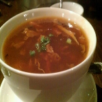

[figure not shown]

```python
# Plotting the test image
  cv2_imshow(X_test[1])
  i=y_test.Label[1]
  i=np.argmax(i)
  if(i == 0):
      plt.title("Bread")
  if(i==1):
      plt.title("Soup")
  if(i==2):
      plt.title("Vegetable-Fruit")

  plt.axis('off')
  plt.show()
```

```python
# Predicting the test image with the best model and storing the prediction value in res variable
  res=model_2.predict(X_test[1].reshape(1,150,150,3))
```

```python
# Applying argmax on the prediction to get the highest index value
  i=np.argmax(res)
  if(i == 0):
      print("Bread")
  if(i==1):
      print("Soup")
  if(i==2):
      print("Vegetable-Fruit")
```

```
Soup
```